# ggplot2 Exercises Solution

## 4.5 Exercises

1. Looks like red line is geom_path() and dark grey line is geom_line(). Thickness of line is determined by the number of survivors. Actually, now that I look at the legend, color (Red or Gray) is determined by direction. There are also labels, so geom_text(aes(label)) is used.
2. *Need help dissecting these graphs*
3. Used maps package with geom_polygon()
4. *Need help dissecting these graphs*
5. *Need help dissecting these graphs*
6. Used maps package with geom_polygon()

## 5.3.1 Exercises

1. You set the geoms most commonly after setting the data first, so ggplot() lists data as the first argument while layer functions list mapping as their first arguments.
2. Help from [StackOverflow](https://stackoverflow.com/questions/48242755/ggplot-number-of-points-according-to-x-value#48243049)

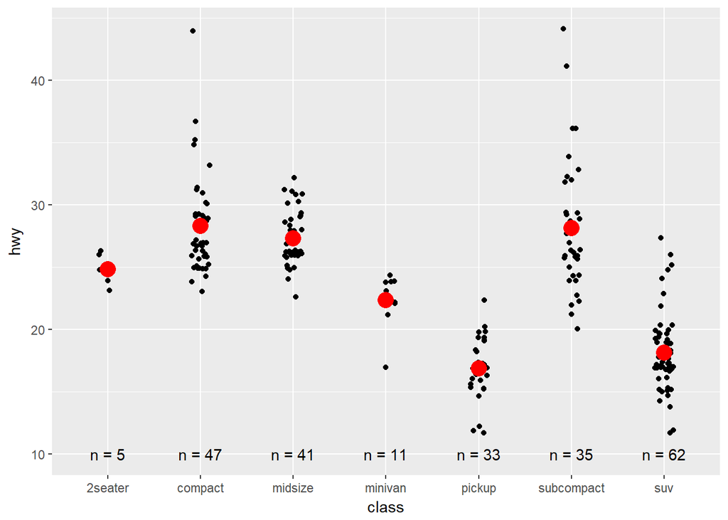

```r
library(tidyverse)
class <- mpg %>%
group_by(class) %>%
summarise(n = n()) %>%
mutate(label = paste0("n = ", n))

ggplot(data = mpg, aes(class, hwy)) +
  geom_jitter(width = 0.1) +
  stat_summary(geom = "point", fun.y = mean, colour = "red", size = 5) +
  geom_text(data = class, aes(y = 10, label = label))
```

## 5.4.3 Exercises

```r
# ggplot(mpg) +
# geom_point(aes(mpg$disp, mpg$hwy))
# can be turned into
ggplot(mpg) +
  geom_point(aes(disp, hwy))
```

```
Error in FUN(X[[i]], ...): object 'disp' not found
```

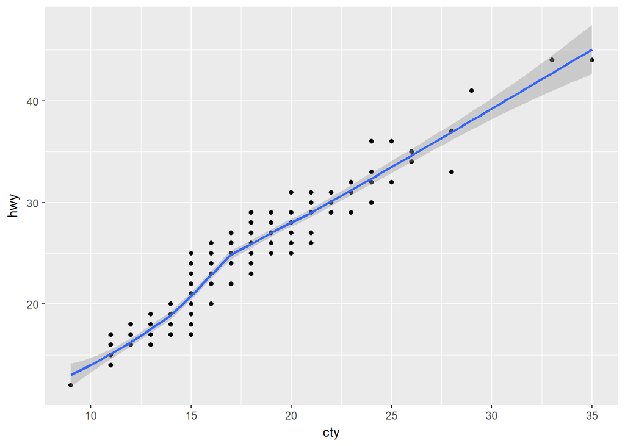

```r
# ggplot() +
# geom_point(mapping = aes(y = hwy, x = cty), data = mpg) +
# geom_smooth(data = mpg, mapping = aes(cty, hwy))
# can be turned into
ggplot(mpg, aes(cty, hwy)) +
  geom_point() +
  geom_smooth()
```

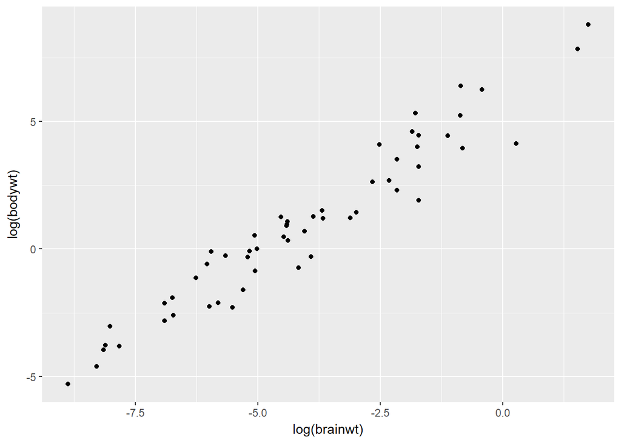

```r
# ggplot(diamonds, aes(carat, price)) +
# geom_point(aes(log(brainwt), log(bodywt)), data = msleep)
# can be turned into
ggplot() +
  geom_point(aes(log(brainwt), log(bodywt)), data = msleep)
```

2.

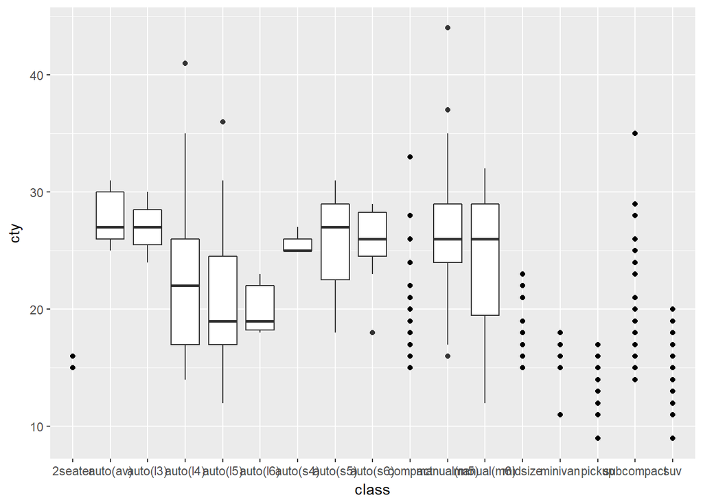

```r
ggplot(mpg) +
  geom_point(aes(class, cty)) +
  geom_boxplot(aes(trans, hwy))
```

*This doesn’t work because there are duplicate x and y values. R simply ignores the latter values,

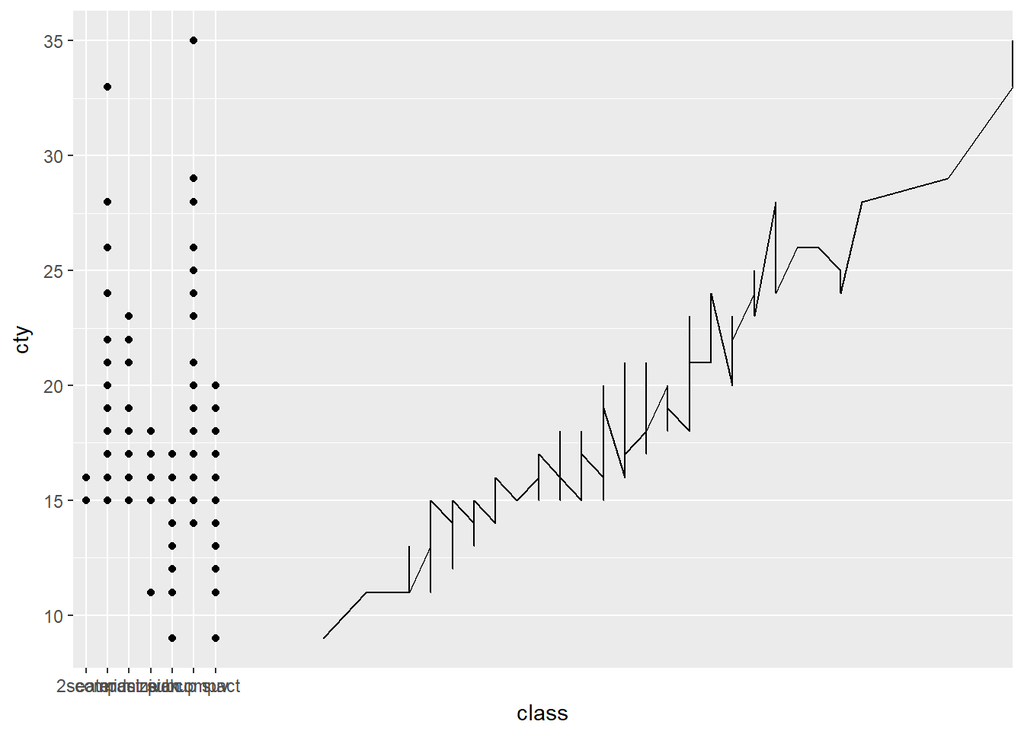

```r
ggplot(mpg) +
  geom_point(aes(class, cty)) +
  geom_line(aes(hwy, cty))
```

```r
# R gets confused and only displays the first x-value on the x-axis

ggplot(mpg) +
  geom_point(aes(hwy, cty)) +
  geom_line(aes(class, cty))
```

```
Error: Discrete value supplied to continuous scale
```

```r
# It gives an error: Discrete value supplied to continuous scale
```

## 5.5.1 Exercises

Question 2. *Need Help*

Question 3. *Need Help*

Question 4.

1. geom_violin()

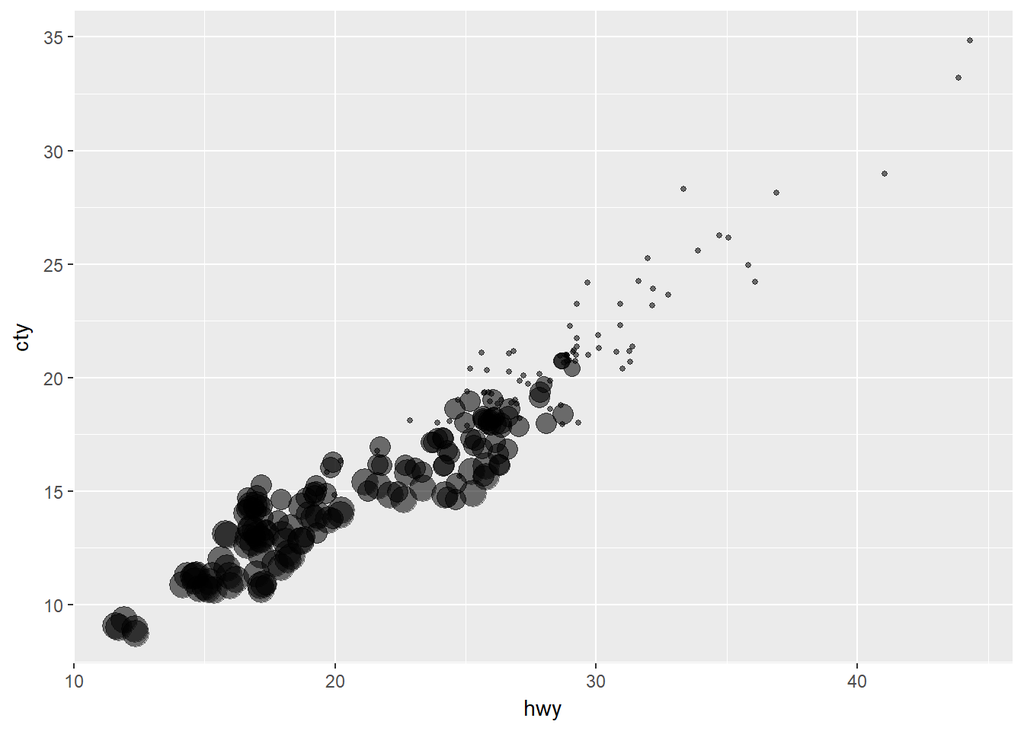

```r
ggplot(mpg) +
  geom_jitter(aes(x = hwy, y = cty, alpha = 0.1, size = cyl)) +
  theme(legend.position = "none")
```

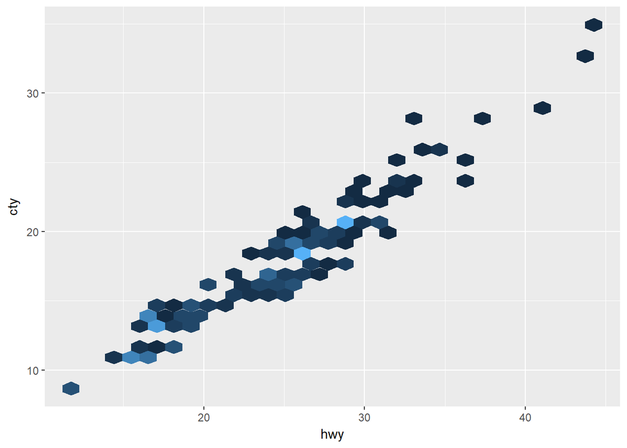

```r
ggplot(mpg) +
  geom_hex(aes(x = hwy, y = cty, size = cyl)) +
  theme(legend.position = "none")
```

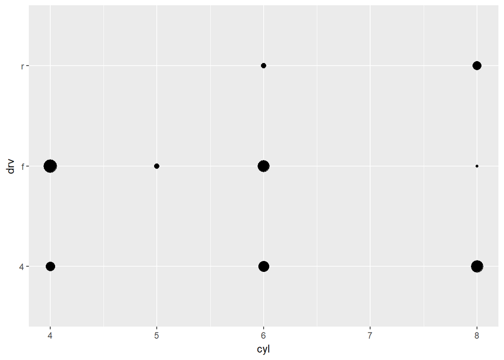

```r
ggplot(mpg, aes(cyl, drv)) +
  geom_count() +
  theme(legend.position = "none")
```

5. geom_area()
6. geom_path

Question 5. * Display how a variable has changed over time: geom_line() or geom_path() * Show the detailed distribution of a single variable: geom_bar() * Focus attention on the overall trend in a large dataset: geom_area() or geom_line() or geom_step() * Draw a map: geom_map() * Label outlying points: geom_label()

## 5.6.2 Exercises

```r
mod <- loess(hwy ~ displ, data = mpg)
smoothed <- data.frame(displ = seq(1.6, 7, length = 50))
pred <- predict(mod, newdata = smoothed, se = TRUE)
smoothed$hwy <- pred$fit
smoothed$hwy_lwr <- pred$fit - 1.96 * pred$se.fit # code to find lower range
smoothed$hwy_upr <- pred$fit + 1.96 * pred$se.fit # code to find upper range

# We should extract from smoothed the outlier points (outside the lower and upper ranges)
outlier <- filter(smoothed, hwy < hwy_lwr | hwy > hwy_upr)
smoothed
```

```
      displ      hwy  hwy_lwr  hwy_upr
1  1.600000 33.09286 31.55842 34.62729
2  1.710204 32.16100 30.90050 33.42149
3  1.820408 31.26635 30.23415 32.29855
4  1.930612 30.41403 29.55725 31.27081
5  2.040816 29.60168 28.86378 30.33957
6  2.151020 28.82979 28.15456 29.50502
7  2.261224 28.09612 27.43616 28.75608
8  2.371429 27.39752 26.72080 28.07424
9  2.481633 26.73611 26.02849 27.44372
10 2.591837 26.11707 25.37791 26.85622
11 2.702041 25.52830 24.76057 26.29604
12 2.812245 24.99810 24.20934 25.78686
13 2.922449 24.53340 23.71434 25.35245
14 3.032653 24.09418 23.23668 24.95168
```

[output cut: 36 more lines]

```r
outlier # there are no outliers!
```

```
[1] displ   hwy     hwy_lwr hwy_upr
<0 rows> (or 0-length row.names)
```

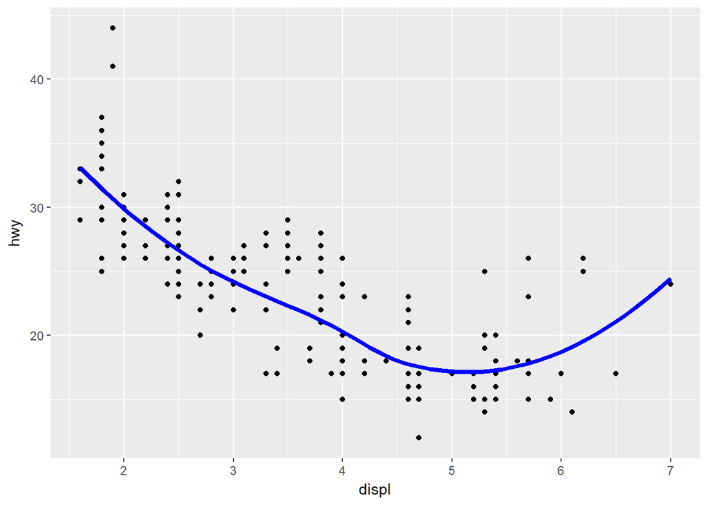

```r
# Solution:
ggplot(mpg, aes(displ, hwy)) +
  geom_point() +
  geom_line(data = smoothed, color = "blue", size = 1.5)
```

- First graph looks like geom_step()
- Second graph
- Third graph

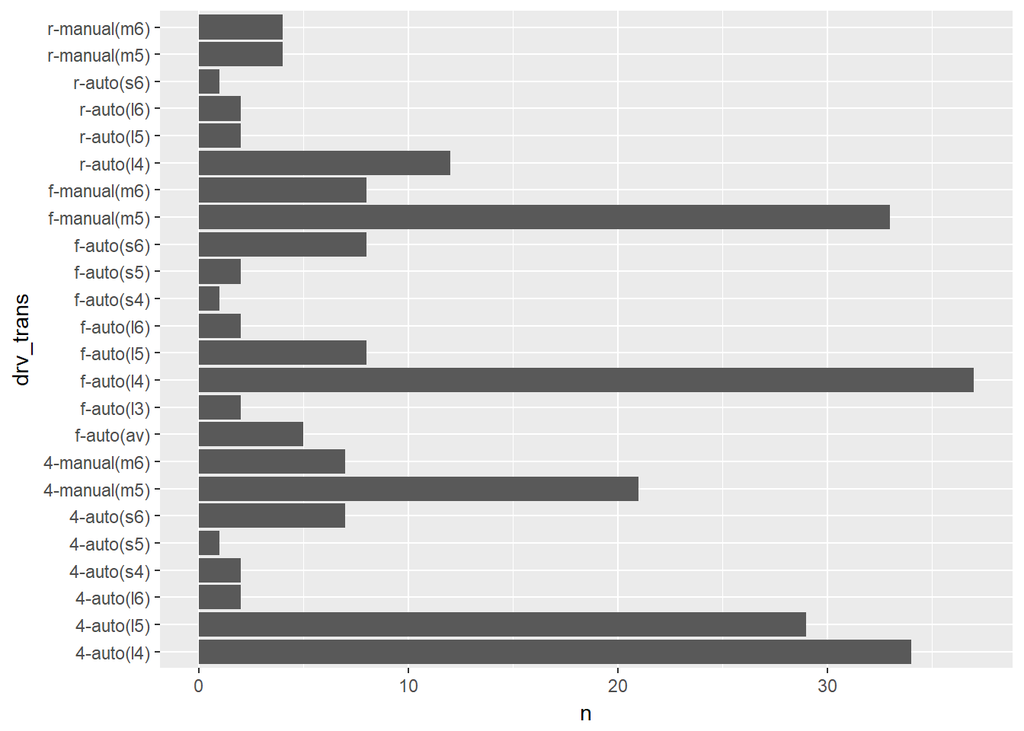

```r
# Help for stat_sum()
# ?stat_sum

mpg %>%
  group_by(drv, trans) %>%
  summarise(n = n()) %>%
  mutate(drv_trans = paste0(drv, "-", trans)) %>%
  ggplot() +
  geom_bar(aes(drv_trans, n), stat = "identity") +
  coord_flip()
```

## 5.7.1 Exericses

```r
?position_nudge()
```

- position_nudge is generally useful for adjusting the position of items on discrete scales by a small amount. Nudging is built in to geom_text because it’s so useful for moving labels a small distance from what they’re labelling.
2. *Need Help here*
3. Borrowed from [U of Chicago](http://cfss.uchicago.edu/r4ds_solutions.html) Rather than adding random noise, geom_count() counts the number of observations at each location, then maps the count to point area. The more observations are located at that area, the larger the point.
4. Borrowed from this [Source](http://www.vizwiz.com/2012/10/stacked-area-chart-vs-line-chart-great.html) With a stacked area plot, it is hard to interpret the magnitude of the area of each color because of the colors below it. With the line plot, you can interpret the trends for each region and area for each region easier. An advantage of a stacked area plot is its differentiability. With colored areas you can easily distinguish between areas underneath the line and thus, distinguish the trends.

## 6.2.1 Exercises

1. *Need Help*

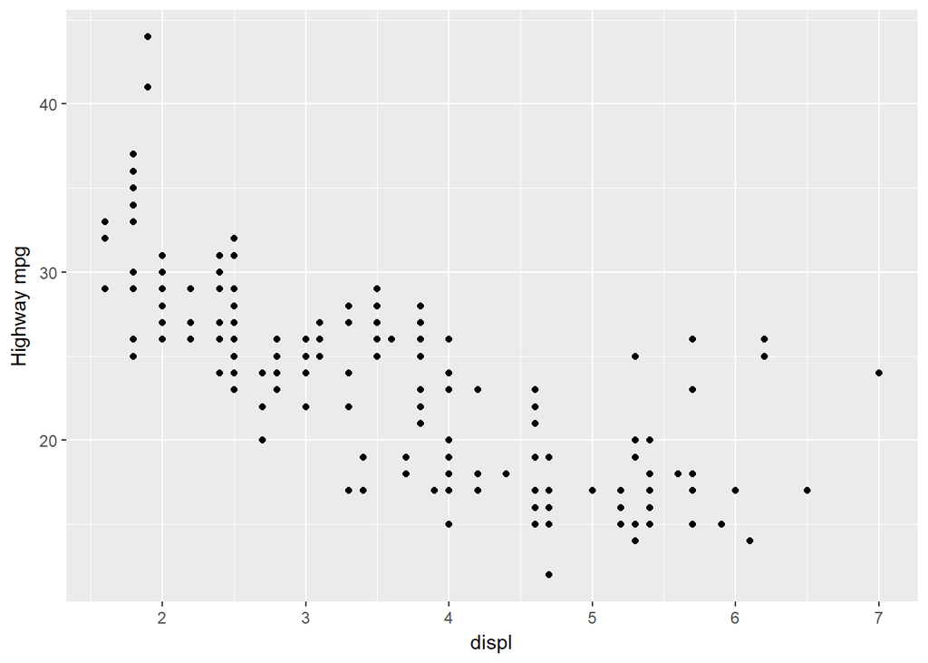

```r
ggplot(mpg, aes(displ, hwy)) +
  geom_point() +
  scale_y_continuous("Highway mpg")
```

## 6.3.3 Exercises

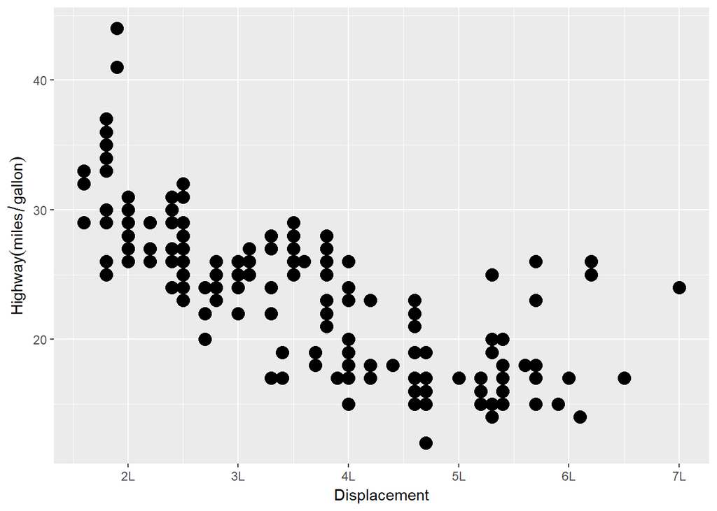

```r
ggplot(mpg, aes(displ, hwy)) +
  geom_point(size = 4) +
  xlab("Displacement") +
  ylab(quote(Highway(miles/gallon))) +
  scale_x_continuous(breaks = c(2, 3, 4, 5, 6, 7),
                     labels = c("2L", "3L", "4L", "5L", "6L", "7L"))
```

2. You can supply NULL, functions, and vectors

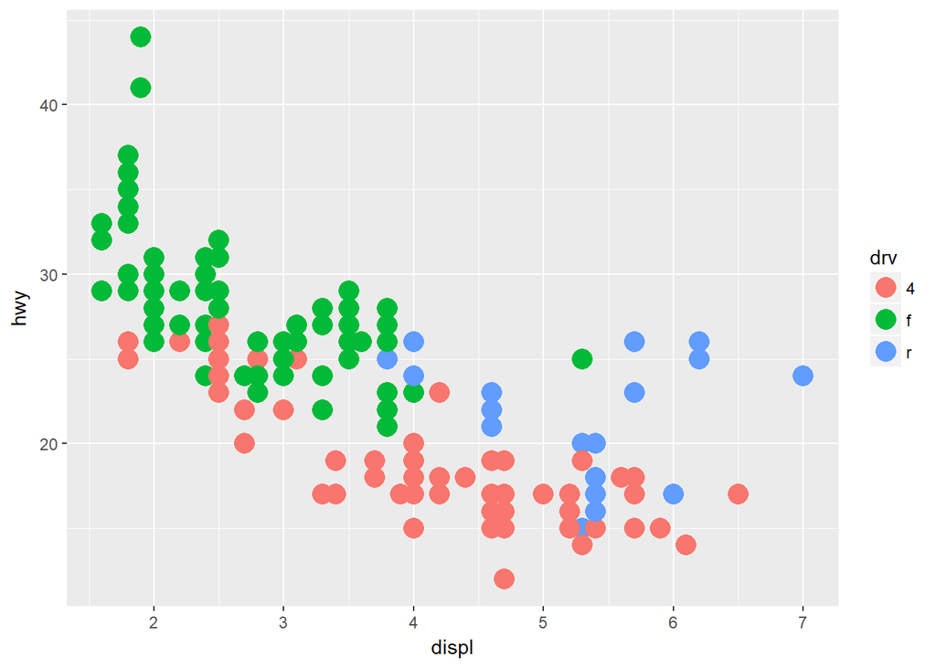

```r
ggplot(mpg, aes(displ, hwy)) +
  geom_point(aes(color = drv), size = 5)
```

4. quote() allows you to make the mathematical expressions. Second part of question is asking for the function that converts numbers into ordinals. This package (toOrdinal) does that: https://cran.r-project.org/web/packages/toOrdinal/toOrdinal.pdf
5. *Need Help*

## 6.4.4 Exercises

1. theme(legend.position = “left”)
2. *Need help*

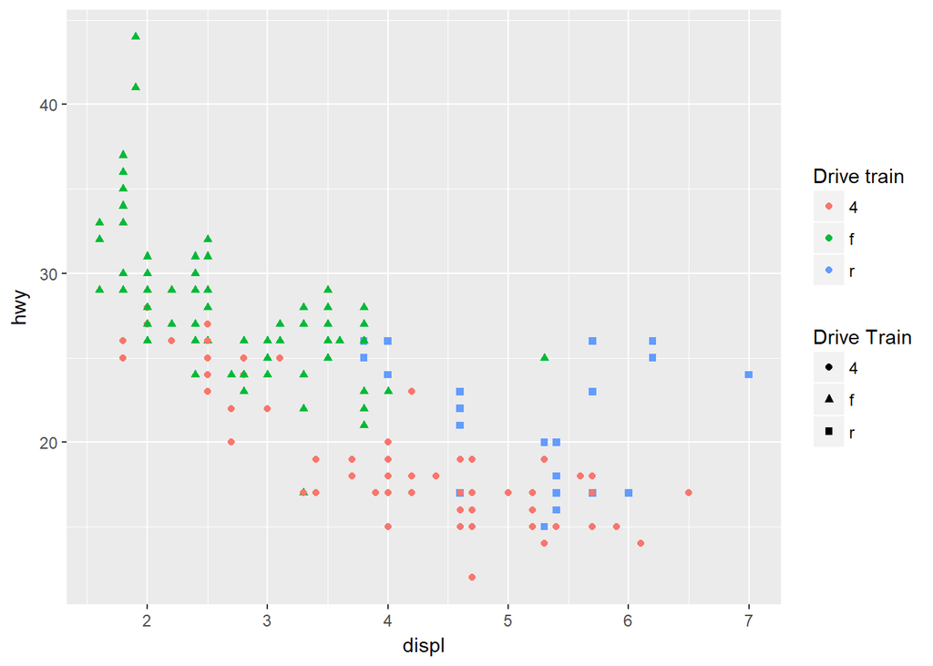

```r
ggplot(mpg, aes(displ, hwy)) +
  geom_point(aes(colour = drv, shape = drv)) +
  scale_colour_discrete("Drive train") +
  scale_shape_discrete("Drive Train")
```

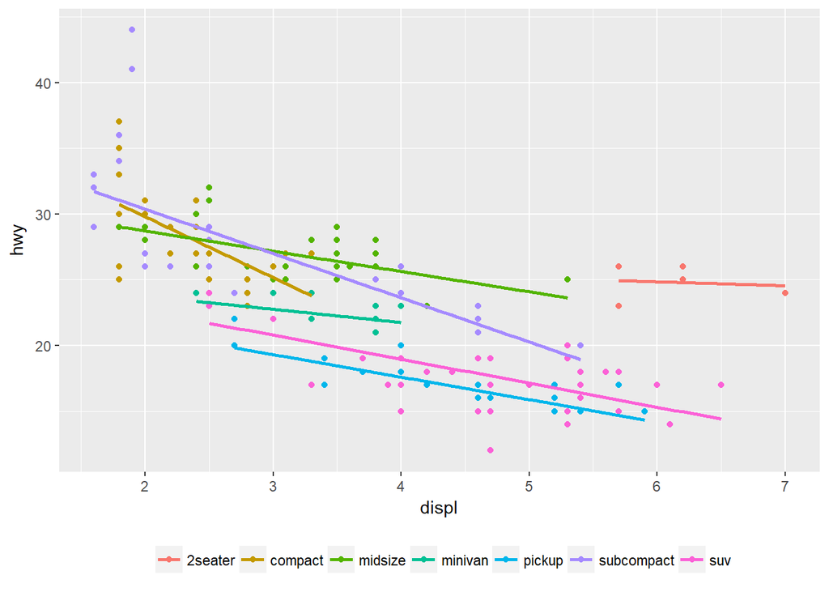

```r
ggplot(mpg, aes(displ, hwy, colour = class)) +
  geom_point() +
  geom_smooth(method = "lm", se = F) +
  theme(legend.position = "bottom", legend.box = "horizontal") +
  scale_color_discrete(NULL) +
  guides(color = guide_legend(nrow = 1))
```

## 6.5.1 Exercises

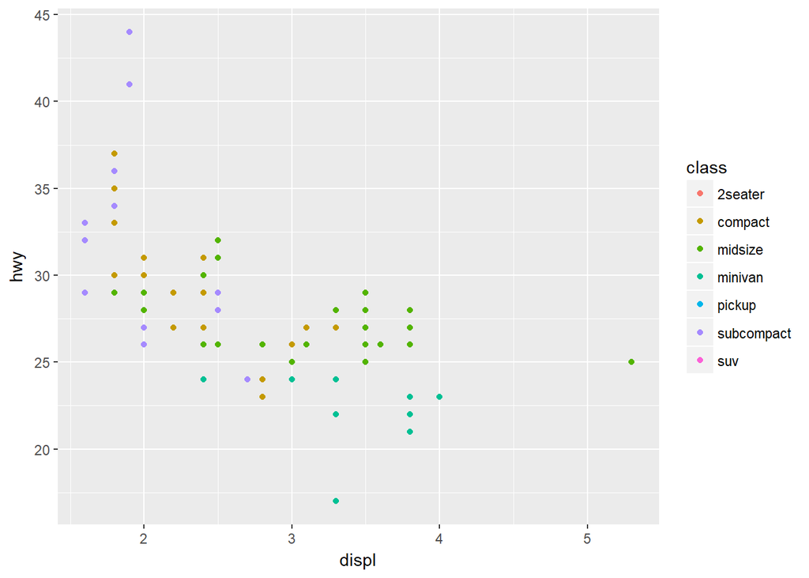

```r
library(tidyverse)
fwd <- subset(mpg, drv == "f")
rwd <- subset(mpg, drv == "r")
ggplot(fwd, aes(displ, hwy, colour = class)) +
  geom_point() +
  scale_colour_discrete(limits = c("2seater", "compact", "midsize", "minivan",
                                   "pickup", "subcompact", "suv"))
```

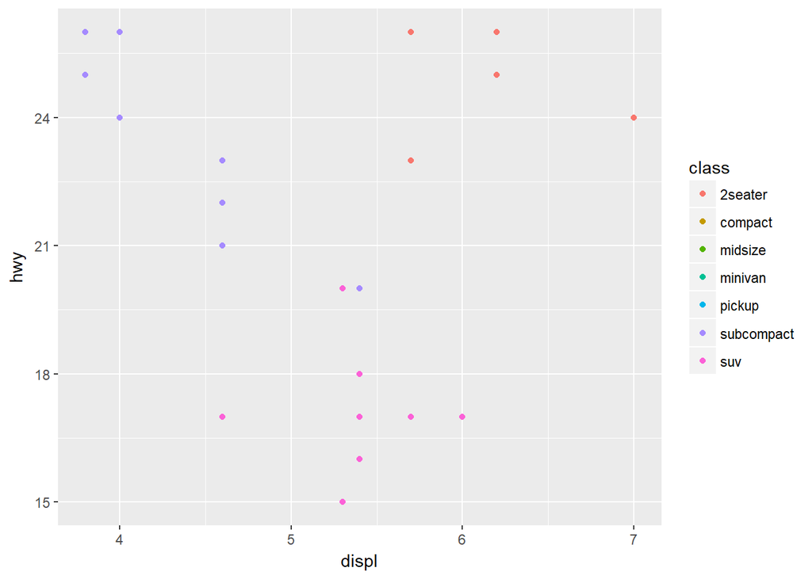

```r
ggplot(rwd, aes(displ, hwy, colour = class)) +
  geom_point() +
  scale_colour_discrete(limits = c("2seater", "compact", "midsize", "minivan",
                                   "pickup", "subcompact", "suv"))
```

```r
# Added scale_colour_discrete()
```

2. *Need help*

```r
expand_limits
```

```
function (...)
{
    data <- data.frame(..., stringsAsFactors = FALSE)
    geom_blank(aes_all(names(data)), data, inherit.aes = FALSE)
}
<environment: namespace:ggplot2>
```

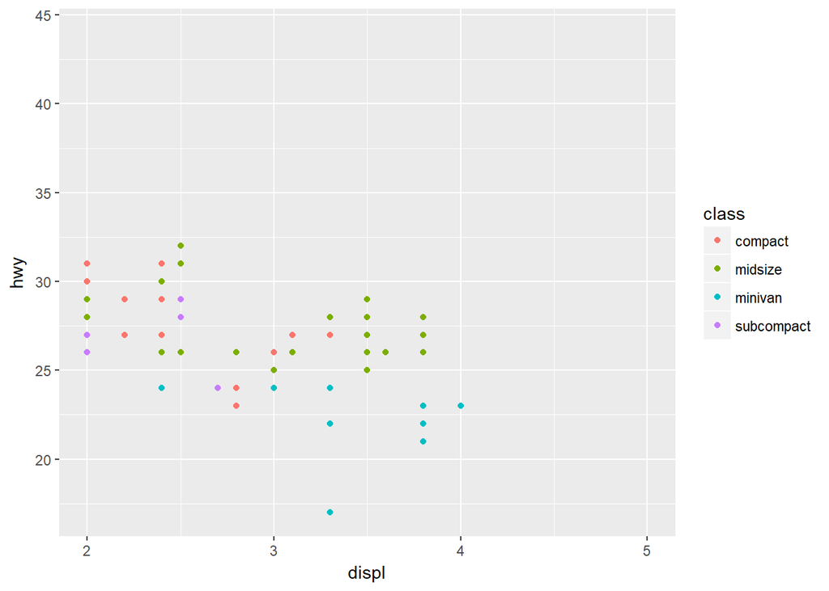

```r
ggplot(fwd, aes(displ, hwy, colour = class)) +
  geom_point() +
  xlim(2,3) +
  xlim(2,5)
```

```r
# As we can see here, ggplot ignores first xlim call and runs the second one.
```

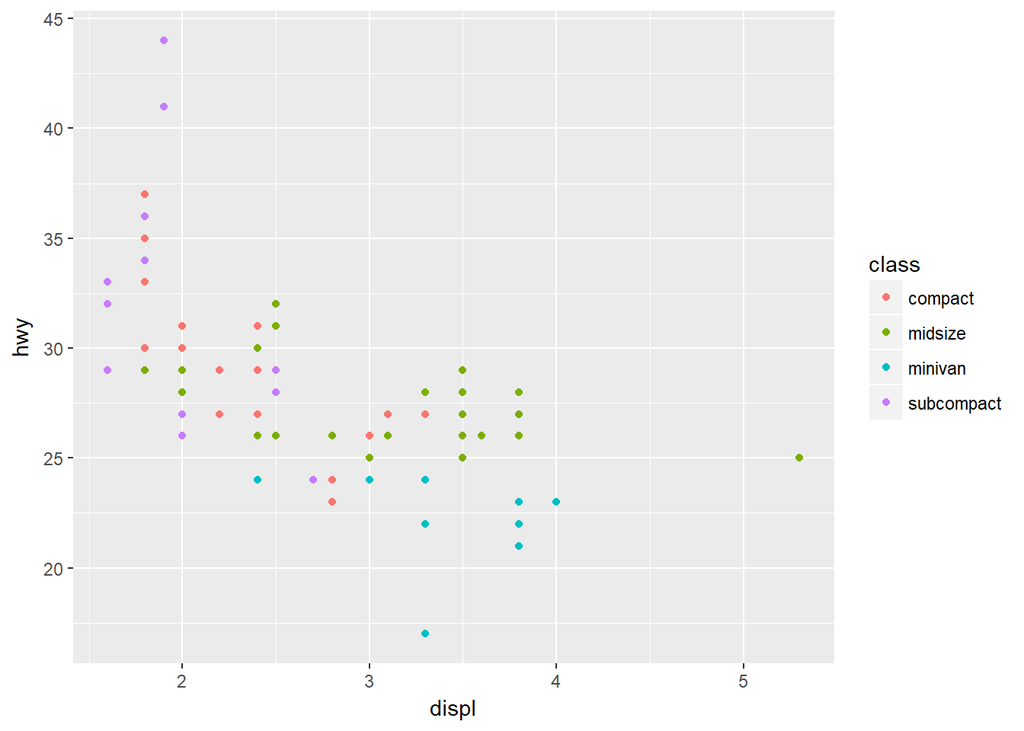

```r
ggplot(fwd, aes(displ, hwy, colour = class)) +
  geom_point() +
  scale_x_continuous(limits = c(NA, NA))
```

```r
# It nullifies limits on the graph.
```

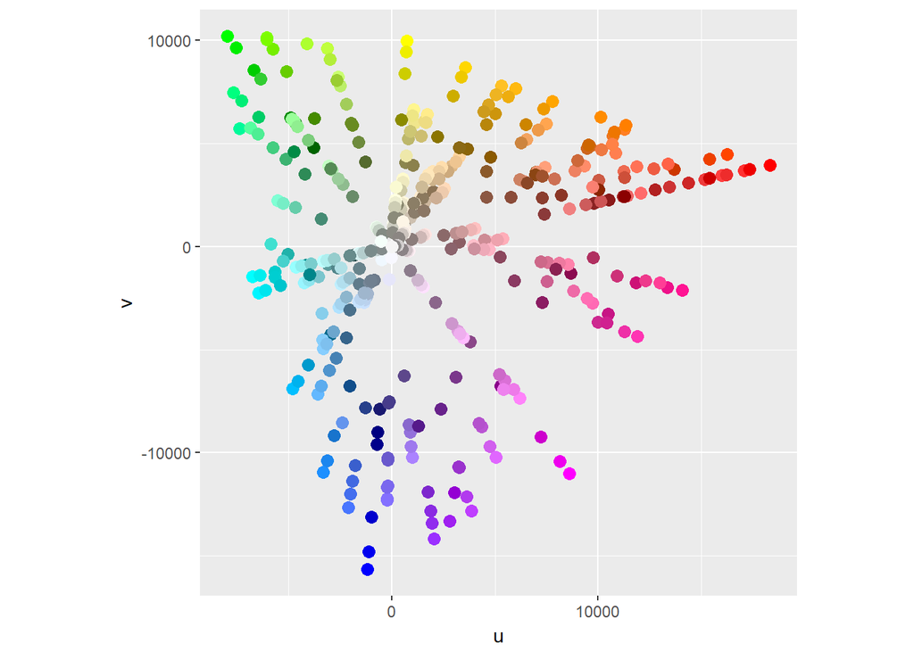

```r
ggplot(luv_colours, aes(u, v)) +
  geom_point(aes(colour = col), size = 3) +
  scale_color_identity() +
  coord_equal()
```

## 6.5.5 Exercises

1. *Need Help*

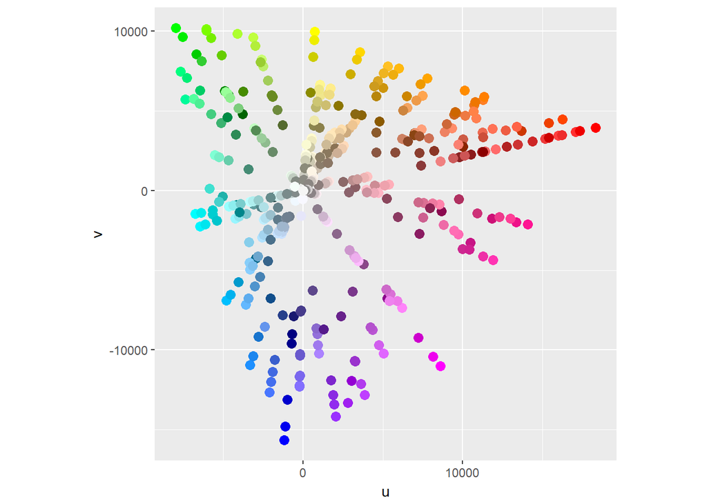

```r
# Save character values of colors in r_color
r_color <- colours()

# ggplot same graph as ones provided in book, except put r_color in color aesthetic.
ggplot(luv_colours, aes(u, v)) +
  geom_point(aes(colour = r_color), size = 3) +
  scale_color_identity() +
  coord_equal()
```